# RQ1: What is the impact of model architecture and training environment on image classification training concerning energy consumption and GPU usage?

Santiago del Rey

## Load and preprocess data

We load the data from the parquet file, filter out the `inception_v3` architecture and the `Desktop Normal User` training environment, and normalize the energy consumption by the total number of images seen during training (converting MJ to J). We also prepare the `gpu_usage` variable.

```r
df <- read_parquet("../data/metrics/processed/clean-dl-training-energy-consumption-dataset.gzip") %>%
  filter(architecture != "inception_v3" & `training environment` != "Desktop Normal User") %>%
  mutate(
    energy = (`energy (MJ)` * 1000000) / `total seen images`, # Convert MJ to J and normalize by total seen images
    training_environment = factor(`training environment`, levels = c("Desktop ML Engineer", "Server")),
    architecture = case_match(architecture,
      "mobilenet_v2" ~ "Mobilenet V2",
      "nasnet_mobile" ~ "NASNet Mobile",
      "resnet50" ~ "ResNet50",
      "xception" ~ "Xception",
      "vgg16" ~ "VGG16"
    ),
    architecture = factor(architecture, levels = c("Mobilenet V2", "NASNet Mobile", "ResNet50", "Xception", "VGG16")),
    gpu_usage = `gpu usage (%)`
  ) %>%
  dplyr::select(energy, gpu_usage, architecture, training_environment)
```

### Outlier filtering functions

```r
# Define a function to filter outliers of a given variable on an input data frame
filter_outliers <- function(df, variable) {
  df %>%
    group_by(architecture, training_environment) %>%
    mutate(
      Q1 = quantile(!!sym(variable), 0.25),
      Q3 = quantile(!!sym(variable), 0.75),
      IQR = Q3 - Q1,
      is_outlier = !!sym(variable) < (Q1 - 1.5 * IQR) | !!sym(variable) > (Q3 + 1.5 * IQR)
    ) %>%
    ungroup() %>%
    filter(!is_outlier) %>%
    dplyr::select(-Q1, -Q3, -IQR, -is_outlier)
}
```

# Energy Consumption Analysis

## Data summary

```r
filtered_energy_data <- df %>%
  filter_outliers("energy")

filtered_energy_data %>%
  group_by(architecture, training_environment) %>%
  summarise(
    mean_energy = mean(energy, na.rm = TRUE),
    sd_energy = sd(energy, na.rm = TRUE),
    min_energy = min(energy, na.rm = TRUE),
    max_energy = max(energy, na.rm = TRUE),
    n = n()
  )
```

| architecture | training_environment | mean_energy | sd_energy | min_energy | max_energy | n |
| --- | --- | --- | --- | --- | --- | --- |
| Mobilenet V2 | Desktop ML Engineer | 0.07997131 | 0.003140598 | 0.07381506 | 0.08438807 | 30 |
| Mobilenet V2 | Server | 0.14134784 | 0.003021697 | 0.13548611 | 0.14669398 | 30 |
| NASNet Mobile | Desktop ML Engineer | 0.18435754 | 0.003079556 | 0.17740872 | 0.18919476 | 30 |
| NASNet Mobile | Server | 0.33901537 | 0.004140010 | 0.33004920 | 0.34579619 | 19 |
| ResNet50 | Desktop ML Engineer | 0.21419984 | 0.007781734 | 0.20295787 | 0.22687862 | 29 |
| ResNet50 | Server | 0.27907660 | 0.013880418 | 0.25748659 | 0.30713353 | 30 |
| Xception | Desktop ML Engineer | 0.26770756 | 0.003229644 | 0.26166462 | 0.27447707 | 30 |
| Xception | Server | 0.33885164 | 0.002489767 | 0.33230082 | 0.34271533 | 28 |
| VGG16 | Desktop ML Engineer | 0.41727207 | 0.005104742 | 0.40749921 | 0.42677788 | 32 |
| VGG16 | Server | 0.39375099 | 0.004474396 | 0.38732800 | 0.40425857 | 24 |

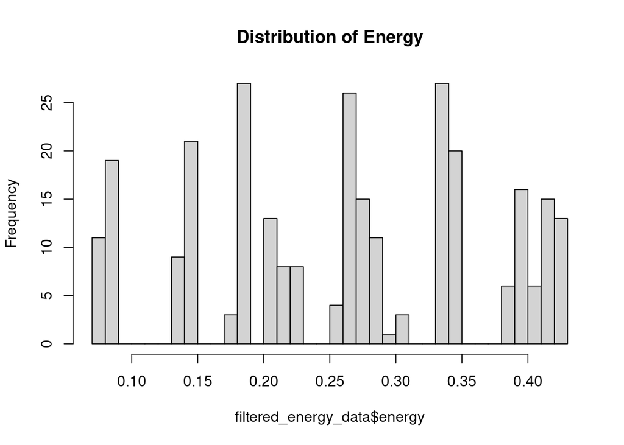

```r
hist(filtered_energy_data$energy, breaks = 30, main = "Distribution of Energy")
```

## Linear Model

Fit a linear model to the energy consumption data, including an interaction term between architecture and training environment.

```r
model_energy <- lm(energy ~ architecture * training_environment, data = filtered_energy_data)
summary(model_energy)
```

```
Call:
lm(formula = energy ~ architecture * training_environment, data = filtered_energy_data)

Residuals:
       Min         1Q     Median         3Q        Max
-0.0215900 -0.0027505  0.0002894  0.0029567  0.0280569

Coefficients:
                                                      Estimate Std. Error
(Intercept)                                           0.079971   0.001116
architectureNASNet Mobile                             0.104386   0.001578
architectureResNet50                                  0.134229   0.001591
architectureXception                                  0.187736   0.001578
architectureVGG16                                     0.337301   0.001553
training_environmentServer                            0.061377   0.001578
architectureNASNet Mobile:training_environmentServer  0.093281   0.002387
architectureResNet50:training_environmentServer       0.003500   0.002241
architectureXception:training_environmentServer       0.009768   0.002251
architectureVGG16:training_environmentServer         -0.084898   0.002283
                                                     t value Pr(>|t|)
(Intercept)                                           71.686  < 2e-16 ***
architectureNASNet Mobile                             66.165  < 2e-16 ***
architectureResNet50                                  84.356  < 2e-16 ***
architectureXception                                 118.995  < 2e-16 ***
architectureVGG16                                    217.217  < 2e-16 ***
training_environmentServer                            38.903  < 2e-16 ***
architectureNASNet Mobile:training_environmentServer  39.076  < 2e-16 ***
architectureResNet50:training_environmentServer        1.562    0.119
architectureXception:training_environmentServer        4.339 2.02e-05 ***
architectureVGG16:training_environmentServer         -37.189  < 2e-16 ***
---
Signif. codes:  0 '***' 0.001 '**' 0.01 '*' 0.05 '.' 0.1 ' ' 1

Residual standard error: 0.00611 on 272 degrees of freedom
Multiple R-squared:  0.9968,    Adjusted R-squared:  0.9967
F-statistic:  9384 on 9 and 272 DF,  p-value: < 2.2e-16
```

## Model diagnostics

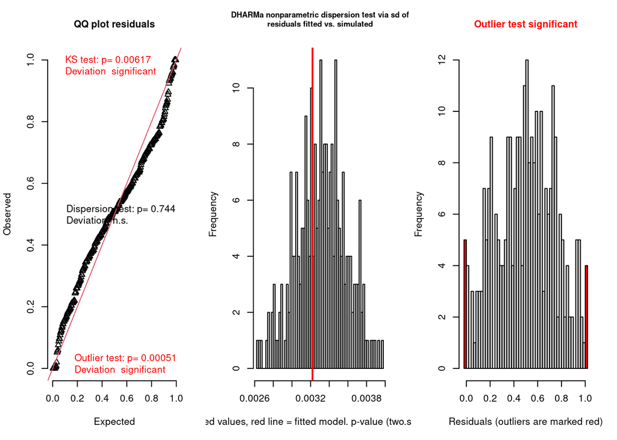

```
$uniformity

    Asymptotic one-sample Kolmogorov-Smirnov test

data:  simulationOutput$scaledResiduals
D = 0.10125, p-value = 0.006167
alternative hypothesis: two-sided


$dispersion

    DHARMa nonparametric dispersion test via sd of residuals fitted vs.
    simulated

data:  simulationOutput
dispersion = 0.97191, p-value = 0.744
alternative hypothesis: two.sided


$outliers

    DHARMa outlier test based on exact binomial test with approximate
    expectations

data:  simulationOutput
outliers at both margin(s) = 9, observations = 282, p-value = 0.0005067
alternative hypothesis: true probability of success is not equal to 0.007968127
95 percent confidence interval:
 0.01469536 0.05971784
sample estimates:
frequency of outliers (expected: 0.00796812749003984 )
                                            0.03191489
```

```r
sim_res_energy <- simulateResiduals(fittedModel = model_energy)
res_df <- data.frame(
  scaled_residuals = sim_res_energy$scaledResiduals,
  predicted = sim_res_energy$fittedPredictedResponse,
  observed = sim_res_energy$observedResponse
)

testResiduals(sim_res_energy)
```

### Remove the outliers detected in the residuals and refit the model

The results of the outlier test indicate that there are some outliers in the residuals. We will remove these outliers based on the scaled residuals, which are the standardized residuals from the model. We will filter out any observations with scaled residuals outside the 2.5%–97.5% quantiles.

```r
# Remove outliers based on the simulated residuals
scaled_res <- sim_res_energy$scaledResiduals

# Identify outliers: residuals outside the 2.5%–97.5% quantiles
lower <- quantile(scaled_res, 0.025)
upper <- quantile(scaled_res, 0.975)

# Mark which residuals are outside the acceptable range
outlier_index <- which(scaled_res < lower | scaled_res > upper)

filtered_energy_data <- filtered_energy_data[-outlier_index, ]

# Show the outliers
filtered_energy_data[outlier_index, ]
```

| energy | gpu_usage | architecture | training_environment |
| --- | --- | --- | --- |
| 0.2088126 | 89.64469 | ResNet50 | Desktop ML Engineer |
| 0.2233504 | 91.13066 | ResNet50 | Desktop ML Engineer |
| 0.2775540 | 78.65497 | ResNet50 | Server |
| 0.2816193 | 79.30789 | ResNet50 | Server |
| 0.2753212 | 80.07398 | ResNet50 | Server |
| 0.2751249 | 79.87418 | ResNet50 | Server |
| 0.2827780 | 80.55567 | ResNet50 | Server |
| 0.2782869 | 77.96074 | ResNet50 | Server |
| 0.2806443 | 78.69622 | ResNet50 | Server |
| 0.3928916 | 90.00763 | VGG16 | Server |

[output cut: 5 more lines]

Refit the model after removing outliers

```r
model_energy <- lm(energy ~ architecture * training_environment, data = filtered_energy_data)
summary(model_energy)
```

```
Call:
lm(formula = energy ~ architecture * training_environment, data = filtered_energy_data)

Residuals:
       Min         1Q     Median         3Q        Max
-0.0098789 -0.0027607  0.0002343  0.0028107  0.0131971

Coefficients:
                                                       Estimate Std. Error
(Intercept)                                           0.0799713  0.0007615
architectureNASNet Mobile                             0.1043862  0.0010769
architectureResNet50                                  0.1328654  0.0011176
architectureXception                                  0.1877362  0.0010769
architectureVGG16                                     0.3373008  0.0010600
training_environmentServer                            0.0613765  0.0010769
architectureNASNet Mobile:training_environmentServer  0.0932813  0.0016295
architectureResNet50:training_environmentServer       0.0077722  0.0016719
architectureXception:training_environmentServer       0.0097676  0.0015365
architectureVGG16:training_environmentServer         -0.0848976  0.0015583
                                                     t value Pr(>|t|)
(Intercept)                                          105.018  < 2e-16 ***
architectureNASNet Mobile                             96.930  < 2e-16 ***
architectureResNet50                                 118.887  < 2e-16 ***
architectureXception                                 174.327  < 2e-16 ***
architectureVGG16                                    318.220  < 2e-16 ***
training_environmentServer                            56.993  < 2e-16 ***
architectureNASNet Mobile:training_environmentServer  57.246  < 2e-16 ***
architectureResNet50:training_environmentServer        4.649 5.35e-06 ***
architectureXception:training_environmentServer        6.357 9.34e-10 ***
architectureVGG16:training_environmentServer         -54.481  < 2e-16 ***
---
Signif. codes:  0 '***' 0.001 '**' 0.01 '*' 0.05 '.' 0.1 ' ' 1

Residual standard error: 0.004171 on 257 degrees of freedom
Multiple R-squared:  0.9986,    Adjusted R-squared:  0.9985
F-statistic: 2.011e+04 on 9 and 257 DF,  p-value: < 2.2e-16
```

Now the diagnostics show that the model is well-fitted without significant outliers and the residuals are normally distributed.

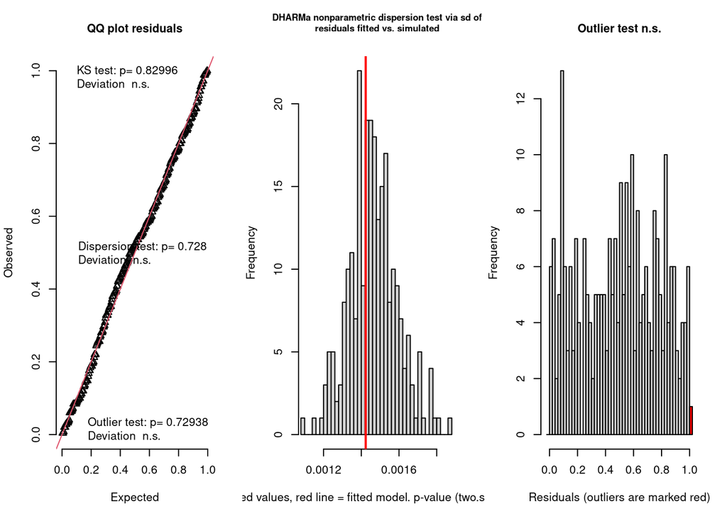

```
$uniformity

    Asymptotic one-sample Kolmogorov-Smirnov test

data:  simulationOutput$scaledResiduals
D = 0.038232, p-value = 0.83
alternative hypothesis: two-sided


$dispersion

    DHARMa nonparametric dispersion test via sd of residuals fitted vs.
    simulated

data:  simulationOutput
dispersion = 0.97184, p-value = 0.728
alternative hypothesis: two.sided


$outliers

    DHARMa outlier test based on exact binomial test with approximate
    expectations

data:  simulationOutput
outliers at both margin(s) = 1, observations = 267, p-value = 0.7294
alternative hypothesis: true probability of success is not equal to 0.007968127
95 percent confidence interval:
 9.481876e-05 2.068980e-02
sample estimates:
frequency of outliers (expected: 0.00796812749003984 )
                                           0.003745318
```

```r
sim_res_energy <- simulateResiduals(fittedModel = model_energy)

testResiduals(sim_res_energy)
```

## Significance testing

```r
options(contrasts = c("contr.sum", "contr.poly")) # sum-to-zero contrasts for Type III
Anova(model_energy, type = 3)
```

|  | Sum Sq | Df | F value | Pr(>F) |
| --- | --- | --- | --- | --- |
| (Intercept) | 0.191862323 | 1 | 11028.849 | 4.239061e-213 |
| architecture | 1.905930209 | 4 | 27389.715 | 0.000000e+00 |
| training_environment | 0.056506167 | 1 | 3248.152 | 7.843837e-148 |
| architecture:training_environment | 0.201770934 | 4 | 2899.607 | 1.909283e-212 |
| Residuals | 0.004470876 | 257 | NA | NA |

## Post hoc tests

```r
emm_energy <- emmeans(model_energy, ~ architecture * training_environment)
pairs(emm_energy, simple = "each", combine = TRUE)
```

```
 training_environment architecture  contrast                      estimate
 Desktop ML Engineer  .             Mobilenet V2 - NASNet Mobile -0.104386
 Desktop ML Engineer  .             Mobilenet V2 - ResNet50      -0.132865
 Desktop ML Engineer  .             Mobilenet V2 - Xception      -0.187736
 Desktop ML Engineer  .             Mobilenet V2 - VGG16         -0.337301
 Desktop ML Engineer  .             NASNet Mobile - ResNet50     -0.028479
 Desktop ML Engineer  .             NASNet Mobile - Xception     -0.083350
 Desktop ML Engineer  .             NASNet Mobile - VGG16        -0.232914
 Desktop ML Engineer  .             ResNet50 - Xception          -0.054871
 Desktop ML Engineer  .             ResNet50 - VGG16             -0.204435
 Desktop ML Engineer  .             Xception - VGG16             -0.149564
 Server               .             Mobilenet V2 - NASNet Mobile -0.197667
 Server               .             Mobilenet V2 - ResNet50      -0.140638
 Server               .             Mobilenet V2 - Xception      -0.197504
 Server               .             Mobilenet V2 - VGG16         -0.252403
 Server               .             NASNet Mobile - ResNet50      0.057030
 Server               .             NASNet Mobile - Xception      0.000164
 Server               .             NASNet Mobile - VGG16        -0.054736
 Server               .             ResNet50 - Xception          -0.056866
 Server               .             ResNet50 - VGG16             -0.111766
 Server               .             Xception - VGG16             -0.054899
 .                    Mobilenet V2  Desktop ML Engineer - Server -0.061377
 .                    NASNet Mobile Desktop ML Engineer - Server -0.154658
 .                    ResNet50      Desktop ML Engineer - Server -0.069149
 .                    Xception      Desktop ML Engineer - Server -0.071144
 .                    VGG16         Desktop ML Engineer - Server  0.023521
      SE  df  t.ratio p.value
 0.00108 257  -96.930  <.0001
 0.00112 257 -118.887  <.0001
 0.00108 257 -174.327  <.0001
 0.00106 257 -318.220  <.0001
 0.00112 257  -25.483  <.0001
 0.00108 257  -77.396  <.0001
 0.00106 257 -219.739  <.0001
 0.00112 257  -49.098  <.0001
 0.00110 257 -185.641  <.0001
 0.00106 257 -141.104  <.0001
 0.00122 257 -161.639  <.0001
 0.00124 257 -113.096  <.0001
 0.00110 257 -180.207  <.0001
 0.00114 257 -220.970  <.0001
 0.00137 257   41.571  <.0001
 0.00124 257    0.132  1.0000
 0.00128 257  -42.736  <.0001
 0.00126 257  -45.130  <.0001
 0.00130 257  -85.940  <.0001
 0.00116 257  -47.317  <.0001
 0.00108 257  -56.993  <.0001
 0.00122 257 -126.468  <.0001
 0.00128 257  -54.069  <.0001
 0.00110 257  -64.913  <.0001
 0.00113 257   20.884  <.0001

P value adjustment: bonferroni method for 25 tests
```

```r
summary(emm_energy)
```

|  | architecture | training_environment | emmean | SE | df | lower.CL | upper.CL |
| --- | --- | --- | --- | --- | --- | --- | --- |
| 1 | Mobilenet V2 | Desktop ML Engineer | 0.07997131 | 0.0007614986 | 257 | 0.07847174 | 0.08147088 |
| 2 | NASNet Mobile | Desktop ML Engineer | 0.18435754 | 0.0007614986 | 257 | 0.18285797 | 0.18585711 |
| 3 | ResNet50 | Desktop ML Engineer | 0.21283673 | 0.0008179807 | 257 | 0.21122593 | 0.21444753 |
| 4 | Xception | Desktop ML Engineer | 0.26770756 | 0.0007614986 | 257 | 0.26620798 | 0.26920713 |
| 5 | VGG16 | Desktop ML Engineer | 0.41727207 | 0.0007373179 | 257 | 0.41582012 | 0.41872403 |
| 6 | Mobilenet V2 | Server | 0.14134784 | 0.0007614986 | 257 | 0.13984827 | 0.14284741 |
| 7 | NASNet Mobile | Server | 0.33901537 | 0.0009568700 | 257 | 0.33713106 | 0.34089967 |
| 8 | ResNet50 | Server | 0.28198545 | 0.0009830905 | 257 | 0.28004951 | 0.28392139 |
| 9 | Xception | Server | 0.33885164 | 0.0007882260 | 257 | 0.33729943 | 0.34040384 |
| 10 | VGG16 | Server | 0.39375099 | 0.0008513813 | 257 | 0.39207441 | 0.39542756 |

Plot the interaction effects

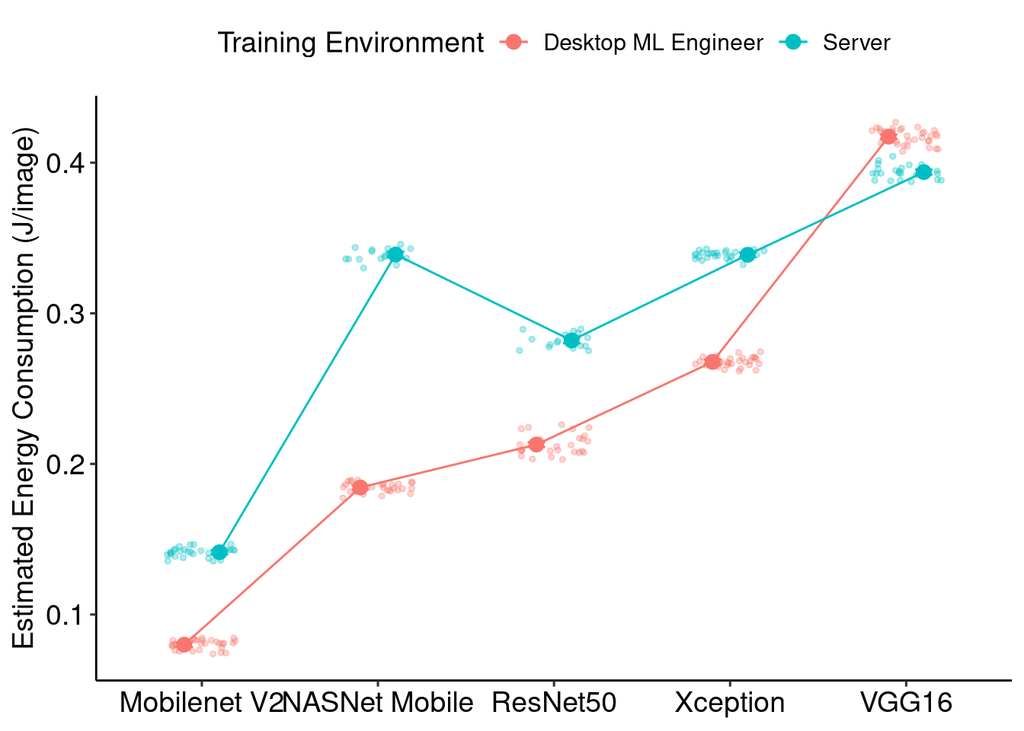

```r
emm_energy_df <- as.data.frame(emm_energy)
emm_df <- emm_energy_df %>%
  mutate(
    energy_estimate = emmean,
    lower_CI = lower.CL,
    upper_CI = upper.CL
  )

# Set the desired order for the x axis
emm_df$architecture <- factor(emm_df$architecture, levels = c("Mobilenet V2", "NASNet Mobile", "ResNet50", "Xception", "VGG16"))

ggplot() +
  # Raw data jittered
  geom_jitter(
    data = filtered_energy_data,
    aes(x = architecture, y = energy, color = training_environment),
    width = 0.2, alpha = 0.3, size = 1
  ) +
  # Estimated points
  geom_point(
    data = emm_df,
    aes(x = architecture, y = energy_estimate, color = training_environment, group = training_environment),
    size = 3, position = position_dodge(width = 0.4)
  ) +
  # Lines connecting estimated points
  geom_line(
    data = emm_df,
    aes(x = architecture, y = energy_estimate, color = training_environment, group = training_environment),
    position = position_dodge(width = 0.4)
  ) +
  # Error bars
  geom_errorbar(
    data = emm_df,
    aes(x = architecture, ymin = lower_CI, ymax = upper_CI, color = training_environment, group = training_environment),
    width = 0.2, position = position_dodge(width = 0.4)
  ) +
  labs(
    title = NULL,
    x = NULL,
    y = "Estimated Energy Consumption (J/image)",
    color = "Training Environment"
  ) +
  theme_pubr() +
  theme(text = element_text(size = 14))
```

# GPU Usage Analysis

## Data summary

```r
# Outlier filtering for gpu_usage (by group)
filtered_gpu_data <- filter_outliers(df, "gpu_usage")

filtered_gpu_data %>%
  group_by(architecture, training_environment) %>%
  summarise(
    mean_gpu_usage = mean(gpu_usage, na.rm = TRUE),
    sd_gpu_usage = sd(gpu_usage, na.rm = TRUE),
    min_gpu_usage = min(gpu_usage, na.rm = TRUE),
    max_gpu_usage = max(gpu_usage, na.rm = TRUE),
    n = n()
  )
```

| architecture | training_environment | mean_gpu_usage | sd_gpu_usage | min_gpu_usage | max_gpu_usage | n |
| --- | --- | --- | --- | --- | --- | --- |
| Mobilenet V2 | Desktop ML Engineer | 56.14850 | 1.7545563 | 52.51105 | 60.34446 | 30 |
| Mobilenet V2 | Server | 22.69289 | 0.5556347 | 21.47188 | 23.48388 | 29 |
| NASNet Mobile | Desktop ML Engineer | 77.39325 | 1.0720708 | 75.73429 | 79.59898 | 30 |
| NASNet Mobile | Server | 42.13204 | 0.5885176 | 41.07506 | 43.11152 | 18 |
| ResNet50 | Desktop ML Engineer | 90.08626 | 0.8116114 | 88.72971 | 91.49827 | 30 |
| ResNet50 | Server | 78.39781 | 1.2022286 | 76.47336 | 80.55567 | 25 |
| Xception | Desktop ML Engineer | 92.92643 | 0.2534629 | 92.50332 | 93.53525 | 30 |
| Xception | Server | 59.62424 | 0.5083171 | 58.62143 | 60.35210 | 30 |
| VGG16 | Desktop ML Engineer | 95.65935 | 0.1247506 | 95.38018 | 95.85964 | 30 |
| VGG16 | Server | 90.03565 | 0.3365034 | 89.52644 | 90.75999 | 25 |

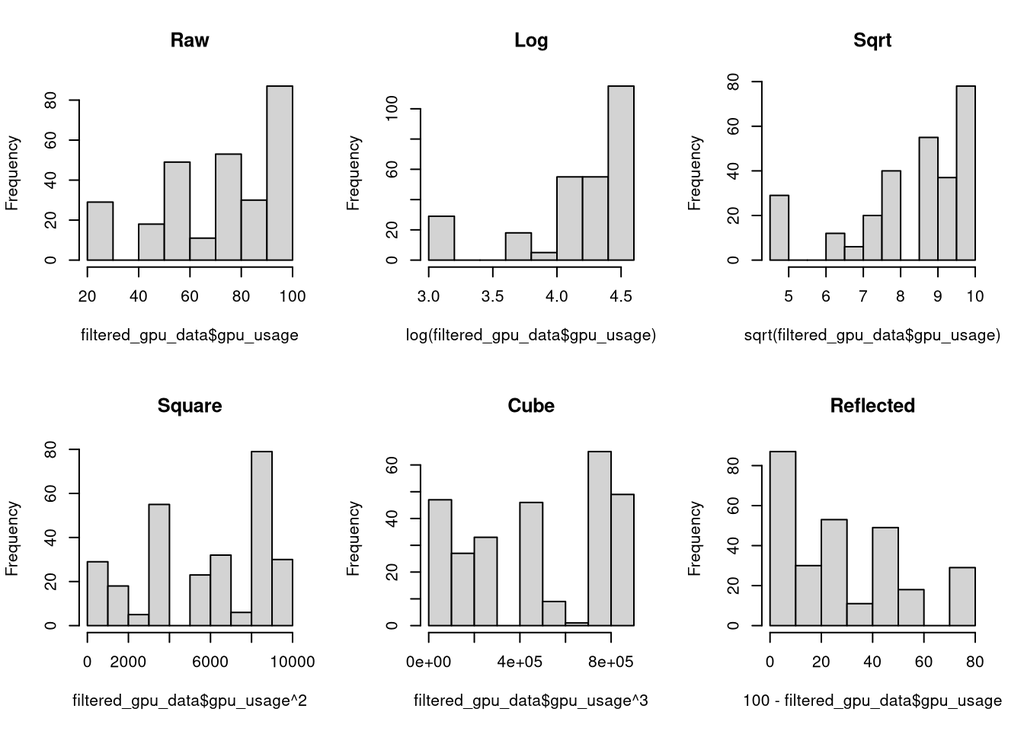

```r
par(mfrow = c(2, 3)) # Set up a 2x3 grid for histograms
hist(filtered_gpu_data$gpu_usage, main = "Raw")
hist(log(filtered_gpu_data$gpu_usage), main = "Log")
hist(sqrt(filtered_gpu_data$gpu_usage), main = "Sqrt")
hist(filtered_gpu_data$gpu_usage^2, main = "Square")
hist(filtered_gpu_data$gpu_usage^3, main = "Cube")
hist(100 - filtered_gpu_data$gpu_usage, main = "Reflected")
```

## Linear Model

```r
max_val <- 100
filtered_gpu_data$gpu_usage_reflected <- sqrt(max_val - filtered_gpu_data$gpu_usage + 1)

model_gpu <- lm(gpu_usage_reflected ~ architecture * training_environment, data = filtered_gpu_data)
summary(model_gpu)
```

```
Call:
lm(formula = gpu_usage_reflected ~ architecture * training_environment,
    data = filtered_gpu_data)

Residuals:
     Min       1Q   Median       3Q      Max
-0.31971 -0.03347  0.00242  0.04529  0.26752

Coefficients:
                                     Estimate Std. Error  t value Pr(>|t|)
(Intercept)                          5.102382   0.005168  987.340   <2e-16 ***
architecture1                        2.670094   0.010006  266.847   <2e-16 ***
architecture2                        1.162570   0.011088  104.853   <2e-16 ***
architecture3                       -1.075424   0.010300 -104.408   <2e-16 ***
architecture4                       -0.465710   0.009944  -46.835   <2e-16 ***
training_environment1               -1.101067   0.005168 -213.063   <2e-16 ***
architecture1:training_environment1  0.024467   0.010006    2.445   0.0151 *
architecture2:training_environment1 -0.306436   0.011088  -27.638   <2e-16 ***
architecture3:training_environment1  0.375464   0.010300   36.452   <2e-16 ***
architecture4:training_environment1 -0.694543   0.009944  -69.847   <2e-16 ***
---
Signif. codes:  0 '***' 0.001 '**' 0.01 '*' 0.05 '.' 0.1 ' ' 1

Residual standard error: 0.08495 on 267 degrees of freedom
Multiple R-squared:  0.9984,    Adjusted R-squared:  0.9984
F-statistic: 1.882e+04 on 9 and 267 DF,  p-value: < 2.2e-16
```

## Model diagnostics

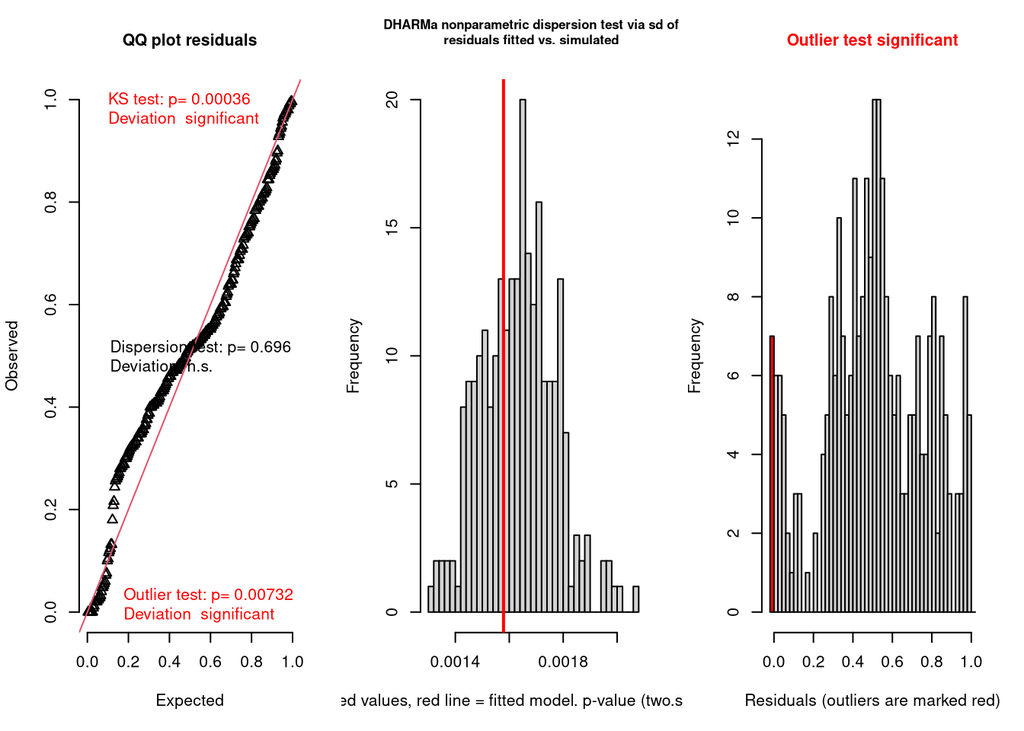

```
$uniformity

    Asymptotic one-sample Kolmogorov-Smirnov test

data:  simulationOutput$scaledResiduals
D = 0.12477, p-value = 0.0003596
alternative hypothesis: two-sided


$dispersion

    DHARMa nonparametric dispersion test via sd of residuals fitted vs.
    simulated

data:  simulationOutput
dispersion = 0.966, p-value = 0.696
alternative hypothesis: two.sided


$outliers

    DHARMa outlier test based on exact binomial test with approximate
    expectations

data:  simulationOutput
outliers at both margin(s) = 7, observations = 277, p-value = 0.007322
alternative hypothesis: true probability of success is not equal to 0.007968127
95 percent confidence interval:
 0.01021919 0.05137200
sample estimates:
frequency of outliers (expected: 0.00796812749003984 )
                                            0.02527076
```

```r
sim_res_gpu <- simulateResiduals(fittedModel = model_gpu)
testResiduals(sim_res_gpu)
```

### Remove the outliers detected in the residuals and refit the model

The results of the outlier test indicate that there are some outliers in the residuals. We will remove these outliers based on the scaled residuals, which are the standardized residuals from the model. We will filter out any observations with scaled residuals outside the 2.5%–97.5% quantiles.

```r
# Remove outliers based on the simulated residuals
scaled_res_gpu <- sim_res_gpu$scaledResiduals
# Identify outliers: residuals outside the 2.5%–97.5% quantiles
lower_gpu <- quantile(scaled_res_gpu, 0.025)
upper_gpu <- quantile(scaled_res_gpu, 0.975)
# Mark which residuals are outside the acceptable range
outlier_index_gpu <- which(scaled_res_gpu < lower_gpu | scaled_res_gpu > upper_gpu)
filtered_gpu_data <- filtered_gpu_data[-outlier_index_gpu, ]
# Show the outliers
filtered_gpu_data[outlier_index_gpu, ]
```

| energy | gpu_usage | architecture | training_environment | gpu_usage_reflected |
| --- | --- | --- | --- | --- |
| 0.07381506 | 58.27013 | Mobilenet V2 | Desktop ML Engineer | 6.536809 |
| 0.07476498 | 57.77954 | Mobilenet V2 | Desktop ML Engineer | 6.574227 |
| 0.07785948 | 58.30124 | Mobilenet V2 | Desktop ML Engineer | 6.534429 |
| 0.18648995 | 77.82679 | NASNet Mobile | Desktop ML Engineer | 4.813856 |
| 0.18170135 | 76.51254 | NASNet Mobile | Desktop ML Engineer | 4.948481 |
| 0.17868282 | 78.90669 | NASNet Mobile | Desktop ML Engineer | 4.700352 |
| 0.27029575 | 92.97042 | Xception | Desktop ML Engineer | 2.833651 |
| 0.21507212 | 89.75678 | ResNet50 | Desktop ML Engineer | 3.353091 |
| 0.22335035 | 91.13066 | ResNet50 | Desktop ML Engineer | 3.141550 |
| 0.28677109 | 78.82763 | ResNet50 | Server | 4.708754 |

[output cut: 2 more lines]

Refit the model after removing outliers

```r
model_gpu <- lm(gpu_usage_reflected ~ architecture * training_environment, data = filtered_gpu_data)
summary(model_gpu)
```

```
Call:
lm(formula = gpu_usage_reflected ~ architecture * training_environment,
    data = filtered_gpu_data)

Residuals:
      Min        1Q    Median        3Q       Max
-0.219257 -0.031102  0.001827  0.039862  0.206205

Coefficients:
                                     Estimate Std. Error  t value Pr(>|t|)
(Intercept)                          5.104791   0.004411 1157.412  < 2e-16 ***
architecture1                        2.670174   0.008631  309.372  < 2e-16 ***
architecture2                        1.172689   0.009451  124.083  < 2e-16 ***
architecture3                       -1.080803   0.008983 -120.313  < 2e-16 ***
architecture4                       -0.468120   0.008352  -56.049  < 2e-16 ***
training_environment1               -1.097392   0.004411 -248.812  < 2e-16 ***
architecture1:training_environment1  0.023280   0.008631    2.697  0.00746 **
architecture2:training_environment1 -0.297583   0.009451  -31.487  < 2e-16 ***
architecture3:training_environment1  0.375148   0.008983   41.761  < 2e-16 ***
architecture4:training_environment1 -0.698218   0.008352  -83.599  < 2e-16 ***
---
Signif. codes:  0 '***' 0.001 '**' 0.01 '*' 0.05 '.' 0.1 ' ' 1

Residual standard error: 0.07093 on 255 degrees of freedom
Multiple R-squared:  0.9989,    Adjusted R-squared:  0.9989
F-statistic: 2.663e+04 on 9 and 255 DF,  p-value: < 2.2e-16
```

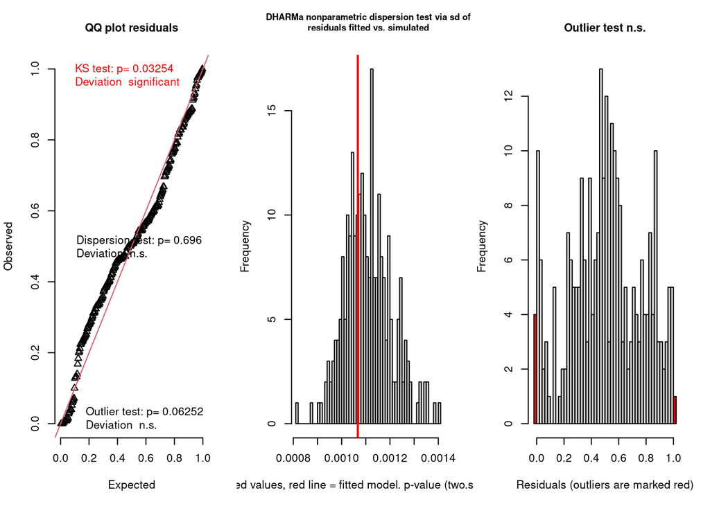

```
$uniformity

    Asymptotic one-sample Kolmogorov-Smirnov test

data:  simulationOutput$scaledResiduals
D = 0.088151, p-value = 0.03254
alternative hypothesis: two-sided


$dispersion

    DHARMa nonparametric dispersion test via sd of residuals fitted vs.
    simulated

data:  simulationOutput
dispersion = 0.96201, p-value = 0.696
alternative hypothesis: two.sided


$outliers

    DHARMa outlier test based on exact binomial test with approximate
    expectations

data:  simulationOutput
outliers at both margin(s) = 5, observations = 265, p-value = 0.06252
alternative hypothesis: true probability of success is not equal to 0.007968127
95 percent confidence interval:
 0.006154051 0.043479730
sample estimates:
frequency of outliers (expected: 0.00796812749003984 )
                                            0.01886792
```

```r
sim_res_gpu <- simulateResiduals(fittedModel = model_gpu)
testResiduals(sim_res_gpu)
```

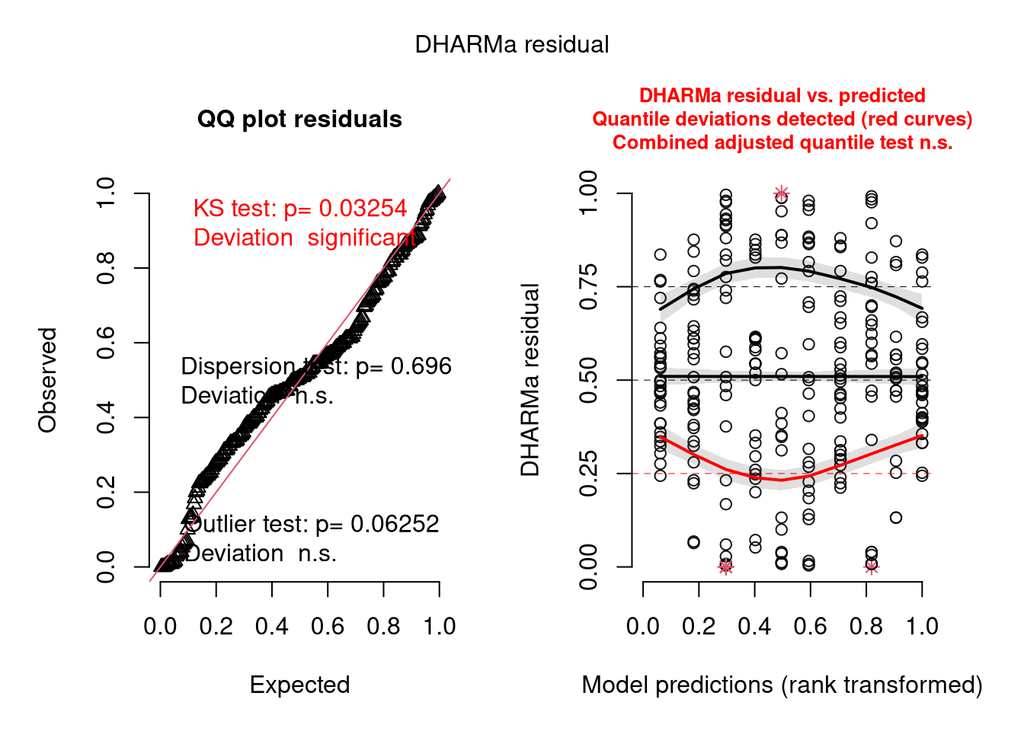

```r
plot(sim_res_gpu)  # DHARMa residual plot
```

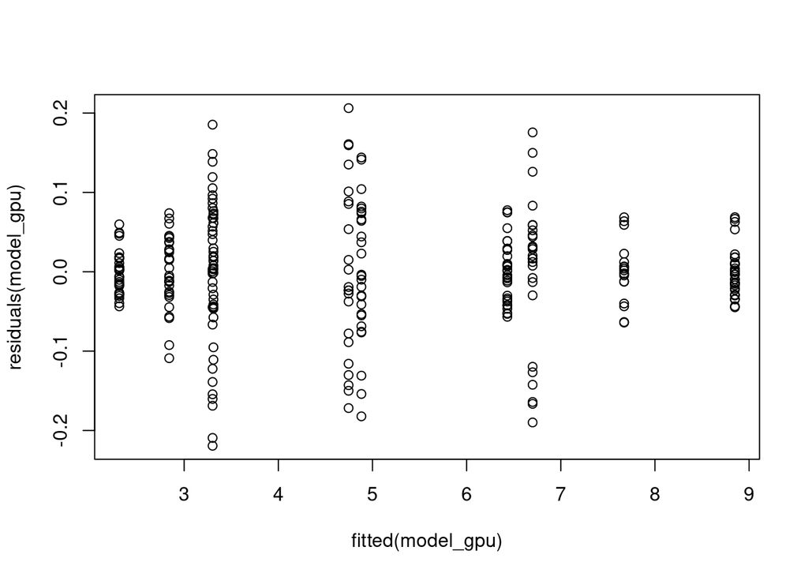

```r
plot(residuals(model_gpu) ~ fitted(model_gpu))  # classic residuals
```

## Significance testing

```r
options(contrasts = c("contr.sum", "contr.poly")) # sum-to-zero contrasts for Type III
Anova(model_gpu, type = 3)
```

|  | Sum Sq | Df | F value | Pr(>F) |
| --- | --- | --- | --- | --- |
| (Intercept) | 6738.689069 | 1 | 1339602.250 | 0.000000e+00 |
| architecture | 807.786435 | 4 | 40145.513 | 0.000000e+00 |
| training_environment | 311.417479 | 1 | 61907.524 | 2.280873e-306 |
| architecture:training_environment | 59.484103 | 4 | 2956.251 | 2.951357e-212 |
| Residuals | 1.282743 | 255 | NA | NA |

## Post hoc tests

```r
emmeans(model_gpu, pairwise ~ architecture * training_environment)
```

```
$emmeans
 architecture  training_environment emmean     SE  df lower.CL upper.CL
 Mobilenet V2  Desktop ML Engineer   6.701 0.0139 255    6.673    6.728
 NASNet Mobile Desktop ML Engineer   4.883 0.0136 255    4.856    4.909
 ResNet50      Desktop ML Engineer   3.302 0.0134 255    3.275    3.328
 Xception      Desktop ML Engineer   2.841 0.0129 255    2.816    2.867
 VGG16         Desktop ML Engineer   2.311 0.0129 255    2.285    2.336
 Mobilenet V2  Server                8.849 0.0132 255    8.823    8.875
 NASNet Mobile Server                7.672 0.0167 255    7.640    7.705
 ResNet50      Server                4.746 0.0151 255    4.716    4.776
 Xception      Server                6.432 0.0129 255    6.407    6.458
 VGG16         Server                3.311 0.0142 255    3.283    3.339

Confidence level used: 0.95

$contrasts
 contrast                                                             estimate
 Mobilenet V2 Desktop ML Engineer - NASNet Mobile Desktop ML Engineer  1.81835
 Mobilenet V2 Desktop ML Engineer - ResNet50 Desktop ML Engineer       3.39911
 Mobilenet V2 Desktop ML Engineer - Xception Desktop ML Engineer       3.85979
 Mobilenet V2 Desktop ML Engineer - VGG16 Desktop ML Engineer          4.39002
 Mobilenet V2 Desktop ML Engineer - Mobilenet V2 Server               -2.14822
 Mobilenet V2 Desktop ML Engineer - NASNet Mobile Server              -0.97160
 Mobilenet V2 Desktop ML Engineer - ResNet50 Server                    1.95462
 Mobilenet V2 Desktop ML Engineer - Xception Server                    0.26857
 Mobilenet V2 Desktop ML Engineer - VGG16 Server                       3.38998
 NASNet Mobile Desktop ML Engineer - ResNet50 Desktop ML Engineer      1.58076
 NASNet Mobile Desktop ML Engineer - Xception Desktop ML Engineer      2.04144
 NASNet Mobile Desktop ML Engineer - VGG16 Desktop ML Engineer         2.57167
 NASNet Mobile Desktop ML Engineer - Mobilenet V2 Server              -3.96657
 NASNet Mobile Desktop ML Engineer - NASNet Mobile Server             -2.78995
 NASNet Mobile Desktop ML Engineer - ResNet50 Server                   0.13627
 NASNet Mobile Desktop ML Engineer - Xception Server                  -1.54978
 NASNet Mobile Desktop ML Engineer - VGG16 Server                      1.57163
 ResNet50 Desktop ML Engineer - Xception Desktop ML Engineer           0.46068
 ResNet50 Desktop ML Engineer - VGG16 Desktop ML Engineer              0.99091
 ResNet50 Desktop ML Engineer - Mobilenet V2 Server                   -5.54733
 ResNet50 Desktop ML Engineer - NASNet Mobile Server                  -4.37071
 ResNet50 Desktop ML Engineer - ResNet50 Server                       -1.44449
 ResNet50 Desktop ML Engineer - Xception Server                       -3.13054
```

[output cut: 55 more lines]

```
 0.0199 255 -122.332  <.0001
 0.0183 255 -225.059  <.0001
 0.0192 255  -52.067  <.0001
 0.0213 255   55.287  <.0001
 0.0201 255  204.602  <.0001
 0.0185 255  130.850  <.0001
 0.0194 255  286.116  <.0001
 0.0225 255  129.815  <.0001
 0.0211 255   58.649  <.0001
 0.0219 255  198.938  <.0001
 0.0199 255  -84.692  <.0001
 0.0207 255   69.230  <.0001
 0.0192 255  162.518  <.0001

P value adjustment: tukey method for comparing a family of 10 estimates
```

```r
emm_gpu <- emmeans(model_gpu, ~ architecture * training_environment)

# back-transform estimated means
emm_gpu_df <- as.data.frame(emm_gpu)
emm_gpu_df <- emm_gpu_df %>%
  mutate(
    gpu_estimate = max_val - emmean^2 + 1,
    lower_CI = max_val - (emmean + SE * qt(0.975, df))^2 + 1,
    upper_CI = max_val - (emmean - SE * qt(0.975, df))^2 + 1
  )
```

Plot the interaction effects

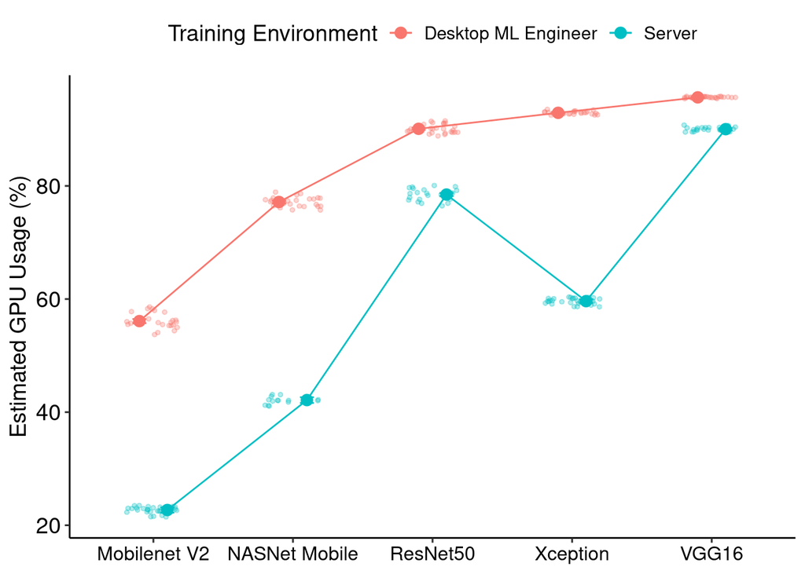

```r
# Set the desired order for the x axis
emm_gpu_df$architecture <- factor(emm_gpu_df$architecture, levels = c("Mobilenet V2", "NASNet Mobile", "ResNet50", "Xception", "VGG16"))

ggplot() +
  # Raw data jittered
  geom_jitter(
    data = filtered_gpu_data,
    aes(x = architecture, y = gpu_usage, color = training_environment),
    width = 0.2, alpha = 0.3, size = 1
  ) +
  # Estimated points
  geom_point(
    data = emm_gpu_df,
    aes(x = architecture, y = gpu_estimate, color = training_environment, group = training_environment),
    size = 3, position = position_dodge(width = 0.4)
  ) +
  # Line connecting the points
  geom_line(
    data = emm_gpu_df,
    aes(x = architecture, y = gpu_estimate, color = training_environment, group = training_environment),
    position = position_dodge(width = 0.4)
  ) +
  # Error bars
  geom_errorbar(
    data = emm_gpu_df,
    aes(x = architecture, ymin = lower_CI, ymax = upper_CI, color = training_environment, group = training_environment),
    width = 0.2, position = position_dodge(width = 0.4)
  ) +
  labs(
    title = NULL,
    x = NULL,
    y = "Estimated GPU Usage (%)",
    color = "Training Environment"
  ) +
  theme_pubr() +
  theme(text = element_text(size = 14),
      axis.text.x = element_text(size = 12))
```

## Visualize estimated energy consumption and gpu usage by architecture and training environment

Show the estimated energy consumption and GPU usage by architecture and training environment in two plots side by side.

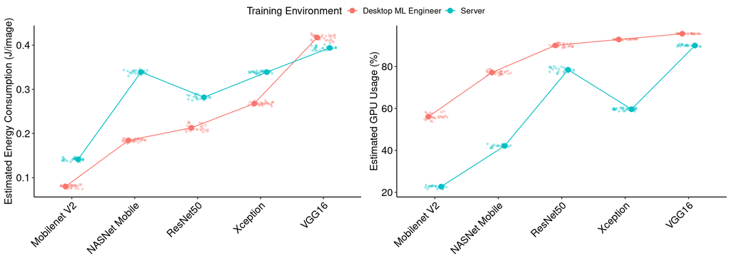

```r
energy_plot <- ggplot() +
  geom_jitter(
    data = filtered_energy_data,
    aes(x = architecture, y = energy, color = training_environment),
    width = 0.2, alpha = 0.3, size = 1
  ) +
  geom_point(
    data = emm_df,
    aes(x = architecture, y = energy_estimate, color = training_environment, group = training_environment),
    size = 3, position = position_dodge(width = 0.4)
  ) +
  geom_line(
    data = emm_df,
    aes(x = architecture, y = energy_estimate, color = training_environment, group = training_environment),
    position = position_dodge(width = 0.4)
  ) +
  geom_errorbar(
    data = emm_df,
    aes(x = architecture, ymin = lower_CI, ymax = upper_CI, color = training_environment, group = training_environment),
    width = 0.2, position = position_dodge(width = 0.4)
  ) +
  labs(
    title = NULL,
    x = NULL,
    y = "Estimated Energy Consumption (J/image)",
    color = "Training Environment"
  ) +
  theme_pubr() +
  theme(text = element_text(size = 14),
        axis.text.x = element_text(angle = 45, hjust = 1))
# Create the GPU usage plot
gpu_plot <- ggplot() +
  geom_jitter(
    data = filtered_gpu_data,
    aes(x = architecture, y = gpu_usage, color = training_environment),
    width = 0.2, alpha = 0.3, size = 1
  ) +
  geom_point(
    data = emm_gpu_df,
    aes(x = architecture, y = gpu_estimate, color = training_environment, group = training_environment),
    size = 3, position = position_dodge(width = 0.4)
  ) +
  geom_line(
    data = emm_gpu_df,
    aes(x = architecture, y = gpu_estimate, color = training_environment, group = training_environment),
    position = position_dodge(width = 0.4)
  ) +
  geom_errorbar(
    data = emm_gpu_df,
    aes(x = architecture, ymin = lower_CI, ymax = upper_CI, color = training_environment, group = training_environment),
    width = 0.2, position = position_dodge(width = 0.4)
  ) +
  labs(
    title = NULL,
    x = NULL,
    y = "Estimated GPU Usage (%)",
    color = "Training Environment"
  ) +
  theme_pubr() +
  theme(text = element_text(size = 14),
        axis.text.x = element_text(angle = 45, hjust = 1))
# grid.arrange(energy_plot, gpu_plot, ncol = 2)

combined_plot <- ggarrange(
  energy_plot, gpu_plot,
  ncol = 2, nrow = 1,
  common.legend = TRUE,
  legend = "top"
)
combined_plot
```